# Reproducible Research Course Project 1

ailifesciences

14/03/2020

```r
knitr::opts_chunk$set(echo = TRUE)
```

## Loading and preprocessing data

1. Load the data (i.e. read.csv())
2. Process/transform the data (if necessary) into a format suitable for your analysis

```r
#Loading data
activity_Data <- read.csv("./activity.csv")

#Loading libraries
library(ggplot2)
library(dplyr)
#Reading data variables
str(activity_Data)
```

```
## 'data.frame':    17568 obs. of  3 variables:
##  $ steps   : int  NA NA NA NA NA NA NA NA NA NA ...
##  $ date    : Factor w/ 61 levels "2012-10-01","2012-10-02",..: 1 1 1 1 1 1 1 1 1 1 ...
##  $ interval: int  0 5 10 15 20 25 30 35 40 45 ...
```

The dataset is stored in a comma-separated-value (CSV) file and there are a total of 17,568 observations in this dataset.

The variables are:

1. steps: Number of steps taking in a 5-minute interval
2. date: The date on which the measurement was taken in YYYY-MM-DD format
3. interval: Identifier for the 5-minute interval in which measurement was taken

## What is mean total number of steps taken per day?

For this part of the assignment, you can ignore the missing values in the dataset.

1. Calculate the total number of steps taken per day

```r
totalSteps <- aggregate(steps~date, activity_Data, sum, na.rm = TRUE)
```

2. Make a histogram of the total number of steps taken each day

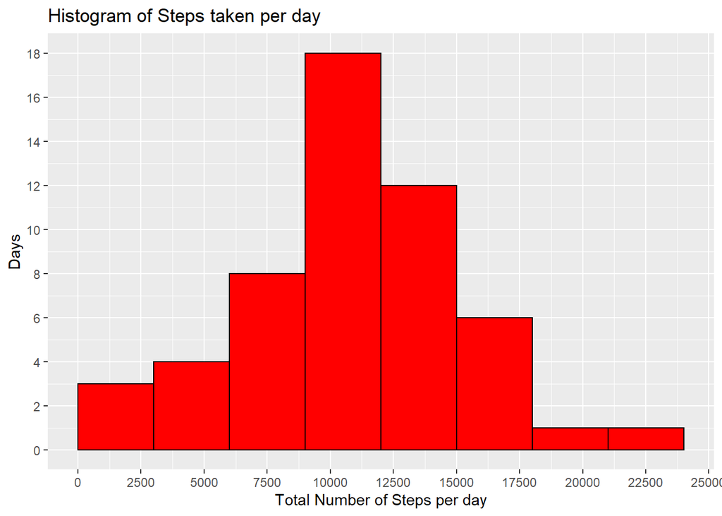

```r
# Plot figure in report
hist <- ggplot(totalSteps, aes(steps))
hist + geom_histogram(boundary = 0, binwidth = 3000, col = "black", fill = "red") + ggtitle("Histogram of Steps taken per day") + xlab("Total Number of Steps per day") + ylab("Days") + scale_x_continuous(breaks=seq(0,25000,2500)) + scale_y_continuous(breaks=seq(0,18,2))
```

```r
# Plot figure in file
png("Steps taken per day")
hist <- ggplot(totalSteps, aes(steps))
hist + geom_histogram(boundary = 0, binwidth = 3000, col = "black", fill = "red") + ggtitle("Histogram of Steps taken per day") + xlab("Total Number of Steps per day") + ylab("Days") + scale_x_continuous(breaks=seq(0,25000,2500)) + scale_y_continuous(breaks=seq(0,18,2))
dev.off()
```

3. Calculate and report the mean and median of the total number of steps taken per day
- The mean total number of steps taken each day is stored in variable meanTotal Steps

```r
meanTotalSteps <- mean(totalSteps$steps)
meanTotalSteps
```

```
## [1] 10766.19
```

- The median total number of steps taken each day is stored in variable medianTotalSteps

```r
medianTotalSteps <- median(totalSteps$steps)
medianTotalSteps
```

```
## [1] 10765
```

## What is the average daily activity pattern?

1. Make a time series plot (type=“l”) of the 5-minute interval (x-axis) and the average number of steps taken, averaged across all days (y-axis)

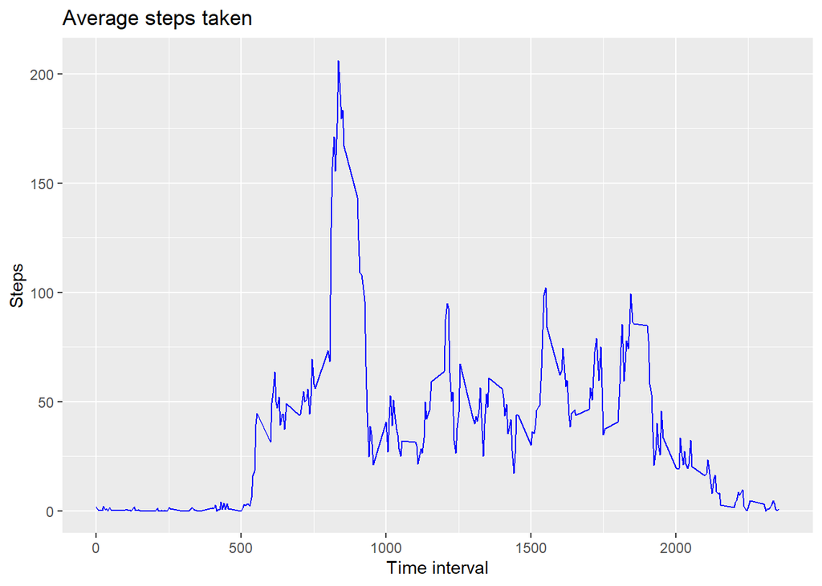

```r
stepsPerInterval<-aggregate(steps~interval, activity_Data, mean, na.rm=TRUE)
stepsPerInterval$time <- stepsPerInterval$interval

#Plotting time series in report

SI <- ggplot(stepsPerInterval, aes(time, steps))
SI + geom_line(col="blue") + ggtitle("Average steps taken") + xlab("Time interval") + ylab("Steps")
```

```r
# Plotting time series in file
png("Average steps taken in time interval")
SI <- ggplot(stepsPerInterval, aes(time, steps))
SI + geom_line(col="blue") + ggtitle("Average steps taken") + xlab("Time interval") + ylab("Steps")
dev.off()
```

2. Which 5-minute interval, on average across all the days in the dataset, contains the maximum number of steps?

```r
stepsPerInterval[which.max(stepsPerInterval[,2]),1]
```

```
## [1] 835
```

## Imputing missing values

Note that there are a number of days/intervals where there are missing values (NA). The presence of missing days may introduce bias into some calculations or summaries of the data.

1. Calculate and report the total number of missing values in the dataset (i.e. the total number of rows with NAs)

```r
totalMissingValue <- sum(is.na(activity_Data$steps))
totalMissingValue
```

```
## [1] 2304
```

```r
meanSteps <-mean(stepsPerInterval$steps)
meanSteps
```

```
## [1] 37.3826
```

3. Create a new dataset that is equal to the original dataset but with the missing data filled in.

```r
activity_DataNew<-activity_Data
for(i in 1:nrow(activity_DataNew)){
    if(is.na(activity_DataNew[i,]$steps)){
        activity_DataNew[i,]$steps <- mean(stepsPerInterval$steps)
    }
}
head(activity_DataNew)
```

```
##     steps       date interval
## 1 37.3826 2012-10-01        0
## 2 37.3826 2012-10-01        5
## 3 37.3826 2012-10-01       10
## 4 37.3826 2012-10-01       15
## 5 37.3826 2012-10-01       20
## 6 37.3826 2012-10-01       25
```

** activity_DataNew is the new dataset which contains no missing values.

4. Make a histogram of the total number of steps taken each day and Calculate and report the mean and median total number of steps taken per day. Do these values differ from the estimates from the first part of the assignment? What is the impact of imputing missing data on the estimates of the total daily number of steps?

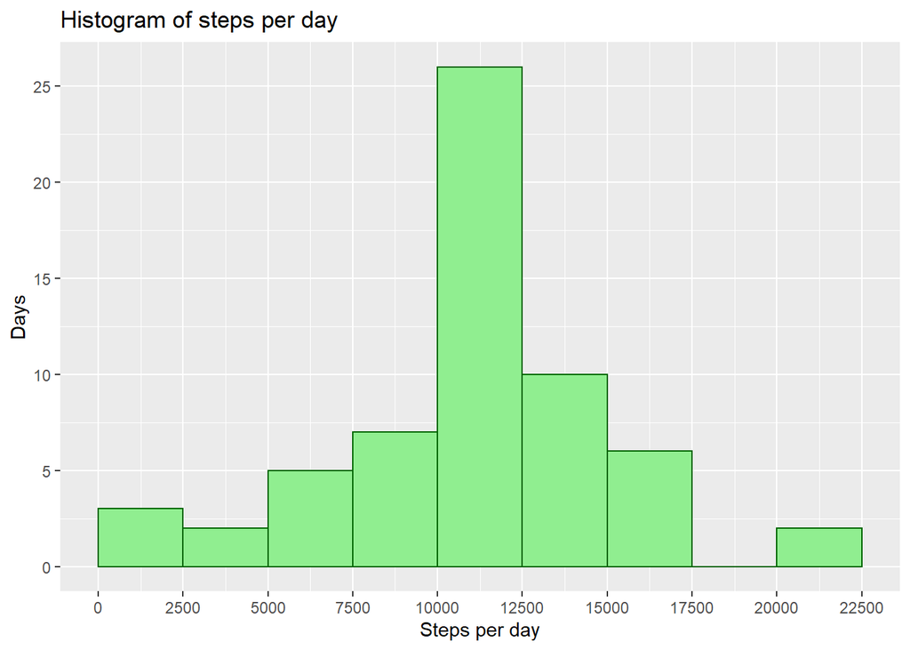

```r
stepsPerDayNew <- aggregate(steps ~ date, data=activity_DataNew, sum)

#Plotting histogram in report

steps <- ggplot(stepsPerDayNew, aes(steps))
steps + geom_histogram(boundary=0, binwidth=2500, col="darkgreen", fill="lightgreen") + ggtitle("Histogram of steps per day") + xlab("Steps per day") + ylab("Days") + scale_x_continuous(breaks=seq(0,25000,2500)) + scale_y_continuous(breaks=seq(0,30,5))
```

```r
#Plotting histogram in file
png("Steps per day")
steps <- ggplot(stepsPerDayNew, aes(steps))
steps + geom_histogram(boundary=0, binwidth=2500, col="darkgreen", fill="lightgreen") + ggtitle("Histogram of steps per day") + xlab("Steps per day") + ylab("Days") + scale_x_continuous(breaks=seq(0,25000,2500)) + scale_y_continuous(breaks=seq(0,30,5))
```

```r
# Calculating mean of steps per day for the new dataset
meanTotalStepsNew <- mean(stepsPerDayNew$steps)
meanTotalStepsNew
```

```
## [1] 10766.19
```

** The mean steps per day for the new dataset is 10766.19

```r
# Calculating mean of steps per day for the new dataset
medianTotalStepsNew <- median(stepsPerDayNew$steps)
medianTotalStepsNew
```

```
## [1] 10766.19
```

** The median steps per day for the new dataset is 10766.19

## Are there differences in activity patterns between weekdays and weekends?

For this part the weekdays() function may be of some help here. Use the dataset with the filled-in missing values for this part.

1. Create a new factor variable in the dataset with two levels – “weekday” and “weekend” indicating whether a given date is a weekday or weekend day.

```r
activity_DataNew$date<-as.Date(activity_DataNew$date)

# Creating variable with day name
activity_DataNew$weekday <- weekdays(activity_DataNew$date)

# Creating new variable to state weekday or weekend
activity_Data2<-activity_DataNew%>%
        mutate(dayType= ifelse(weekdays(activity_DataNew$date)=="Saturday" | weekdays(activity_DataNew$date)=="Sunday", "Weekend", "Weekday"))
str(activity_Data2)
```

```
## 'data.frame':    17568 obs. of  5 variables:
##  $ steps   : num  37.4 37.4 37.4 37.4 37.4 ...
##  $ date    : Date, format: "2012-10-01" "2012-10-01" ...
##  $ interval: int  0 5 10 15 20 25 30 35 40 45 ...
##  $ weekday : chr  "Monday" "Monday" "Monday" "Monday" ...
##  $ dayType : chr  "Weekday" "Weekday" "Weekday" "Weekday" ...
```

2. Make a panel plot containing a time series plot (i.e. type=“l”) of the 5-minute interval (x-axis) and the average number of steps taken, averaged across all weekday days or weekend days (y-axis). See the README file in the GitHub repository to see an example of what this plot should look like using simulated data.

```r
steps_DayandInterval<-activity_Data2 %>%
  group_by(dayType, interval) %>%
  summarize(steps_Day=sum(steps))

str(steps_DayandInterval)
```

```
## Classes 'grouped_df', 'tbl_df', 'tbl' and 'data.frame':  576 obs. of  3 variables:
##  $ dayType  : chr  "Weekday" "Weekday" "Weekday" "Weekday" ...
##  $ interval : int  0 5 10 15 20 25 30 35 40 45 ...
##  $ steps_Day: num  315 242 231 232 228 ...
##  - attr(*, "groups")=Classes 'tbl_df', 'tbl' and 'data.frame':   2 obs. of  2 variables:
##   ..$ dayType: chr  "Weekday" "Weekend"
##   ..$ .rows  :List of 2
##   .. ..$ : int  1 2 3 4 5 6 7 8 9 10 ...
##   .. ..$ : int  289 290 291 292 293 294 295 296 297 298 ...
##   ..- attr(*, ".drop")= logi TRUE
```

[figure not shown]

```r
names(steps_DayandInterval) <- c("dayType", "interval", "steps_Day")

library(lattice)
# Plotting average steps by DayType in report
xyplot(steps_Day ~ interval | dayType, steps_DayandInterval, type = "l", layout = c(1, 2), xlab = "Intervals", ylab = "Steps", main = "Average Steps within Intervals by DayType")
```

```r
# Plotting average steps by DayType in file
png("Average steps by daytype")
xyplot(steps_Day ~ interval | dayType, steps_DayandInterval, type = "l", layout = c(1, 2), xlab = "Intervals", ylab = "Steps", main = "Average Steps within Intervals by DayType")
dev.off()
```

# Reproducible Research Course Project 1

ailifesciences

14/03/2020

```r
knitr::opts_chunk$set(echo = TRUE)
```

## Loading and preprocessing data

1. Load the data (i.e. read.csv())
2. Process/transform the data (if necessary) into a format suitable for your analysis

```r
#Loading data
activity_Data <- read.csv("./activity.csv")

#Loading libraries
library(ggplot2)
library(dplyr)
#Reading data variables
str(activity_Data)
```

```
## 'data.frame':    17568 obs. of  3 variables:
##  $ steps   : int  NA NA NA NA NA NA NA NA NA NA ...
##  $ date    : Factor w/ 61 levels "2012-10-01","2012-10-02",..: 1 1 1 1 1 1 1 1 1 1 ...
##  $ interval: int  0 5 10 15 20 25 30 35 40 45 ...
```

The dataset is stored in a comma-separated-value (CSV) file and there are a total of 17,568 observations in this dataset.

The variables are:

1. steps: Number of steps taking in a 5-minute interval
2. date: The date on which the measurement was taken in YYYY-MM-DD format
3. interval: Identifier for the 5-minute interval in which measurement was taken

## What is mean total number of steps taken per day?

For this part of the assignment, you can ignore the missing values in the dataset.

1. Calculate the total number of steps taken per day

```r
totalSteps <- aggregate(steps~date, activity_Data, sum, na.rm = TRUE)
```

2. Make a histogram of the total number of steps taken each day

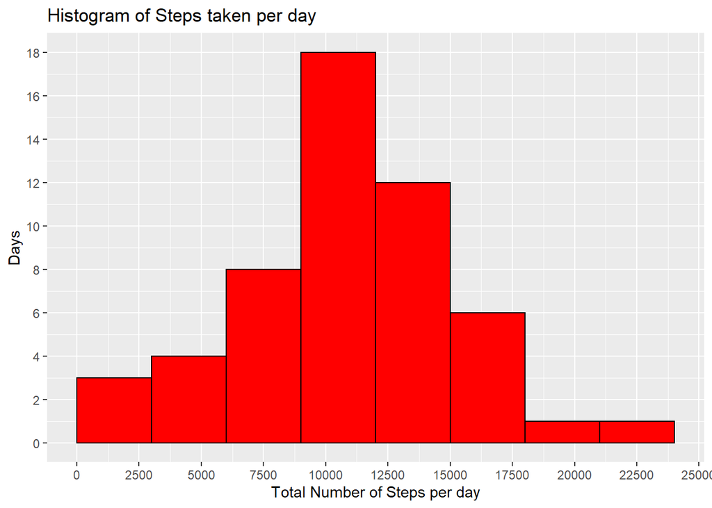

```r
# Plot figure in report
hist <- ggplot(totalSteps, aes(steps))
hist + geom_histogram(boundary = 0, binwidth = 3000, col = "black", fill = "red") + ggtitle("Histogram of Steps taken per day") + xlab("Total Number of Steps per day") + ylab("Days") + scale_x_continuous(breaks=seq(0,25000,2500)) + scale_y_continuous(breaks=seq(0,18,2))
```

```r
# Plot figure in file
png("Steps taken per day")
hist <- ggplot(totalSteps, aes(steps))
hist + geom_histogram(boundary = 0, binwidth = 3000, col = "black", fill = "red") + ggtitle("Histogram of Steps taken per day") + xlab("Total Number of Steps per day") + ylab("Days") + scale_x_continuous(breaks=seq(0,25000,2500)) + scale_y_continuous(breaks=seq(0,18,2))
dev.off()
```

3. Calculate and report the mean and median of the total number of steps taken per day
- The mean total number of steps taken each day is stored in variable meanTotal Steps

```r
meanTotalSteps <- mean(totalSteps$steps)
meanTotalSteps
```

```
## [1] 10766.19
```

- The median total number of steps taken each day is stored in variable medianTotalSteps

```r
medianTotalSteps <- median(totalSteps$steps)
medianTotalSteps
```

```
## [1] 10765
```

## What is the average daily activity pattern?

1. Make a time series plot (type=“l”) of the 5-minute interval (x-axis) and the average number of steps taken, averaged across all days (y-axis)

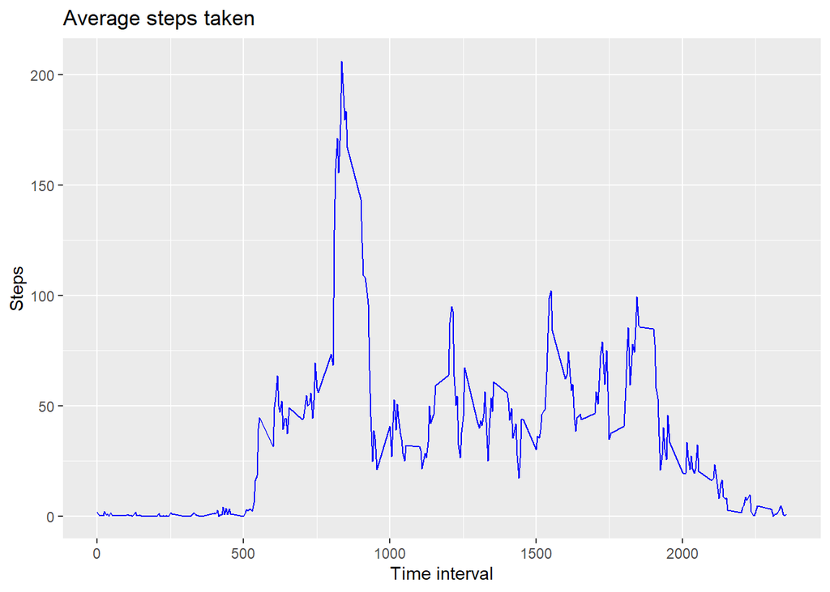

```r
stepsPerInterval<-aggregate(steps~interval, activity_Data, mean, na.rm=TRUE)
stepsPerInterval$time <- stepsPerInterval$interval

#Plotting time series in report

SI <- ggplot(stepsPerInterval, aes(time, steps))
SI + geom_line(col="blue") + ggtitle("Average steps taken") + xlab("Time interval") + ylab("Steps")
```

```r
# Plotting time series in file
png("Average steps taken in time interval")
SI <- ggplot(stepsPerInterval, aes(time, steps))
SI + geom_line(col="blue") + ggtitle("Average steps taken") + xlab("Time interval") + ylab("Steps")
dev.off()
```

2. Which 5-minute interval, on average across all the days in the dataset, contains the maximum number of steps?

```r
stepsPerInterval[which.max(stepsPerInterval[,2]),1]
```

```
## [1] 835
```

## Imputing missing values

Note that there are a number of days/intervals where there are missing values (NA). The presence of missing days may introduce bias into some calculations or summaries of the data.

1. Calculate and report the total number of missing values in the dataset (i.e. the total number of rows with NAs)

```r
totalMissingValue <- sum(is.na(activity_Data$steps))
totalMissingValue
```

```
## [1] 2304
```

```r
meanSteps <-mean(stepsPerInterval$steps)
meanSteps
```

```
## [1] 37.3826
```

3. Create a new dataset that is equal to the original dataset but with the missing data filled in.

```r
activity_DataNew<-activity_Data
for(i in 1:nrow(activity_DataNew)){
    if(is.na(activity_DataNew[i,]$steps)){
        activity_DataNew[i,]$steps <- mean(stepsPerInterval$steps)
    }
}
head(activity_DataNew)
```

```
##     steps       date interval
## 1 37.3826 2012-10-01        0
## 2 37.3826 2012-10-01        5
## 3 37.3826 2012-10-01       10
## 4 37.3826 2012-10-01       15
## 5 37.3826 2012-10-01       20
## 6 37.3826 2012-10-01       25
```

** activity_DataNew is the new dataset which contains no missing values.

4. Make a histogram of the total number of steps taken each day and Calculate and report the mean and median total number of steps taken per day. Do these values differ from the estimates from the first part of the assignment? What is the impact of imputing missing data on the estimates of the total daily number of steps?

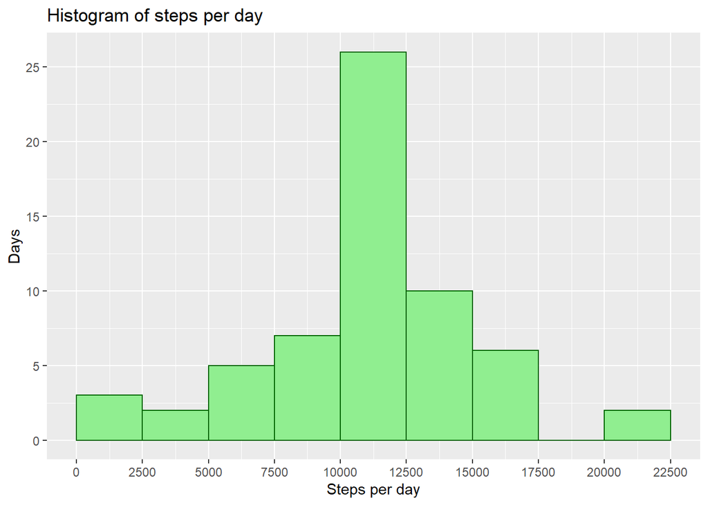

```r
stepsPerDayNew <- aggregate(steps ~ date, data=activity_DataNew, sum)

#Plotting histogram in report

steps <- ggplot(stepsPerDayNew, aes(steps))
steps + geom_histogram(boundary=0, binwidth=2500, col="darkgreen", fill="lightgreen") + ggtitle("Histogram of steps per day") + xlab("Steps per day") + ylab("Days") + scale_x_continuous(breaks=seq(0,25000,2500)) + scale_y_continuous(breaks=seq(0,30,5))
```

```r
#Plotting histogram in file
png("Steps per day")
steps <- ggplot(stepsPerDayNew, aes(steps))
steps + geom_histogram(boundary=0, binwidth=2500, col="darkgreen", fill="lightgreen") + ggtitle("Histogram of steps per day") + xlab("Steps per day") + ylab("Days") + scale_x_continuous(breaks=seq(0,25000,2500)) + scale_y_continuous(breaks=seq(0,30,5))
```

```r
# Calculating mean of steps per day for the new dataset
meanTotalStepsNew <- mean(stepsPerDayNew$steps)
meanTotalStepsNew
```

```
## [1] 10766.19
```

** The mean steps per day for the new dataset is 10766.19

```r
# Calculating mean of steps per day for the new dataset
medianTotalStepsNew <- median(stepsPerDayNew$steps)
medianTotalStepsNew
```

```
## [1] 10766.19
```

** The median steps per day for the new dataset is 10766.19

## Are there differences in activity patterns between weekdays and weekends?

For this part the weekdays() function may be of some help here. Use the dataset with the filled-in missing values for this part.

1. Create a new factor variable in the dataset with two levels – “weekday” and “weekend” indicating whether a given date is a weekday or weekend day.

```r
activity_DataNew$date<-as.Date(activity_DataNew$date)

# Creating variable with day name
activity_DataNew$weekday <- weekdays(activity_DataNew$date)

# Creating new variable to state weekday or weekend
activity_Data2<-activity_DataNew%>%
        mutate(dayType= ifelse(weekdays(activity_DataNew$date)=="Saturday" | weekdays(activity_DataNew$date)=="Sunday", "Weekend", "Weekday"))
str(activity_Data2)
```

```
## 'data.frame':    17568 obs. of  5 variables:
##  $ steps   : num  37.4 37.4 37.4 37.4 37.4 ...
##  $ date    : Date, format: "2012-10-01" "2012-10-01" ...
##  $ interval: int  0 5 10 15 20 25 30 35 40 45 ...
##  $ weekday : chr  "Monday" "Monday" "Monday" "Monday" ...
##  $ dayType : chr  "Weekday" "Weekday" "Weekday" "Weekday" ...
```

2. Make a panel plot containing a time series plot (i.e. type=“l”) of the 5-minute interval (x-axis) and the average number of steps taken, averaged across all weekday days or weekend days (y-axis). See the README file in the GitHub repository to see an example of what this plot should look like using simulated data.

```r
steps_DayandInterval<-activity_Data2 %>%
  group_by(dayType, interval) %>%
  summarize(steps_Day=sum(steps))

str(steps_DayandInterval)
```

```
## Classes 'grouped_df', 'tbl_df', 'tbl' and 'data.frame':  576 obs. of  3 variables:
##  $ dayType  : chr  "Weekday" "Weekday" "Weekday" "Weekday" ...
##  $ interval : int  0 5 10 15 20 25 30 35 40 45 ...
##  $ steps_Day: num  315 242 231 232 228 ...
##  - attr(*, "groups")=Classes 'tbl_df', 'tbl' and 'data.frame':   2 obs. of  2 variables:
##   ..$ dayType: chr  "Weekday" "Weekend"
##   ..$ .rows  :List of 2
##   .. ..$ : int  1 2 3 4 5 6 7 8 9 10 ...
##   .. ..$ : int  289 290 291 292 293 294 295 296 297 298 ...
##   ..- attr(*, ".drop")= logi TRUE
```

[figure not shown]

```r
names(steps_DayandInterval) <- c("dayType", "interval", "steps_Day")

library(lattice)
# Plotting average steps by DayType in report
xyplot(steps_Day ~ interval | dayType, steps_DayandInterval, type = "l", layout = c(1, 2), xlab = "Intervals", ylab = "Steps", main = "Average Steps within Intervals by DayType")
```

```r
# Plotting average steps by DayType in file
png("Average steps by daytype")
xyplot(steps_Day ~ interval | dayType, steps_DayandInterval, type = "l", layout = c(1, 2), xlab = "Intervals", ylab = "Steps", main = "Average Steps within Intervals by DayType")
dev.off()
```